# HW3

Sheet

```
import warnings

import matplotlib.pyplot as plt
import pandas as pd
import seaborn as sns
from sklearn.ensemble import RandomForestClassifier, GradientBoostingClassifier
from sklearn.model_selection import train_test_split

warnings.filterwarnings("ignore")
```

```
df = pd.read_csv('hotel_bookings.csv')
df.head(5)
```

[interactive chart not shown]

```
df.info()
```

<class 'pandas.core.frame.DataFrame'>  
RangeIndex: 119390 entries, 0 to 119389  
Data columns (total 32 columns):  
# Column Non-Null Count Dtype  
--- ------ -------------- -----  
0 hotel 119390 non-null object  
1 is_canceled 119390 non-null int64  
2 lead_time 119390 non-null int64  
3 arrival_date_year 119390 non-null int64  
4 arrival_date_month 119390 non-null object  
5 arrival_date_week_number 119390 non-null int64  
6 arrival_date_day_of_month 119390 non-null int64  
7 stays_in_weekend_nights 119390 non-null int64  
8 stays_in_week_nights 119390 non-null int64  
9 adults 119390 non-null int64  
10 children 119386 non-null float64  
11 babies 119390 non-null int64  
12 meal 119390 non-null object  
13 country 118902 non-null object  
14 market_segment 119390 non-null object  
15 distribution_channel 119390 non-null object  
16 is_repeated_guest 119390 non-null int64  
17 previous_cancellations 119390 non-null int64  
18 previous_bookings_not_canceled 119390 non-null int64  
19 reserved_room_type 119390 non-null object  
20 assigned_room_type 119390 non-null object  
21 booking_changes 119390 non-null int64  
22 deposit_type 119390 non-null object  
23 agent 103050 non-null float64  
24 company 6797 non-null float64  
25 days_in_waiting_list 119390 non-null int64  
26 customer_type 119390 non-null object  
27 adr 119390 non-null float64  
28 required_car_parking_spaces 119390 non-null int64  
29 total_of_special_requests 119390 non-null int64  
30 reservation_status 119390 non-null object  
31 reservation_status_date 119390 non-null object  
dtypes: float64(4), int64(16), object(12)  
memory usage: 29.1+ MB

[output not shown]

```
df.describe()
```

[interactive chart not shown]

```
df.hist(figsize=(20,14))
plt.show()
```

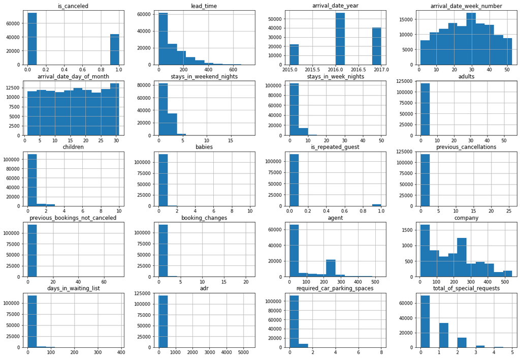

```
nan_replacements = {"country": "Unknown", "agent": 0, "company": 0}
df = df.fillna(nan_replacements)
df["meal"].replace("Undefined", "SC", inplace=True)
nan_value = float("NaN")
df.replace(nan_value, 0.0,  inplace=True)

# Some rows contain entreis with 0 adults, 0 children and 0 babies.
zero_guests = list(df.loc[df["adults"]
                   + df["children"]
                   + df["babies"]==0].index)
df.drop(df.index[zero_guests], inplace=True)
df.drop_duplicates(inplace=True)
```

```
plt.figure(figsize = (16,16))
ax=sns.heatmap(df.corr(), annot=True)
plt.show()
```

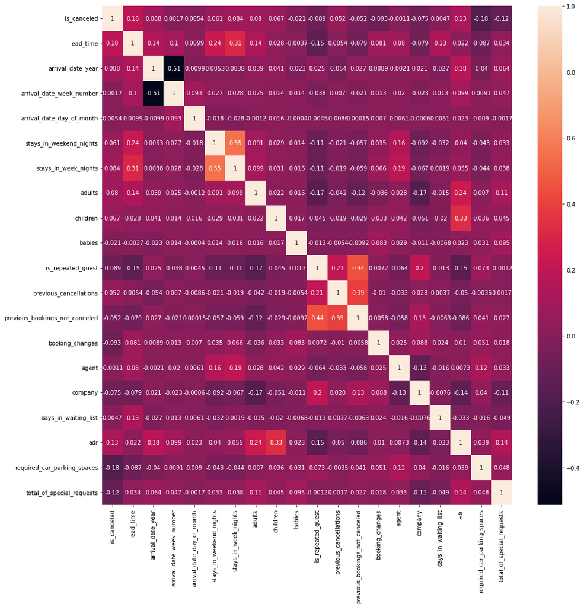

[output not shown]

```
df = df.drop(['reservation_status_date'],axis=1)
```

```
num_features = ['lead_time','arrival_date_year','arrival_date_week_number','stays_in_weekend_nights',
               'stays_in_week_nights','adults','children','babies','is_repeated_guest','previous_cancellations',
                'previous_bookings_not_canceled','booking_changes','days_in_waiting_list','adr','required_car_parking_spaces',
                'total_of_special_requests']
cat_features = ['hotel', 'arrival_date_month','meal','country','market_segment',
                'distribution_channel','reserved_room_type','assigned_room_type','deposit_type','agent',
                'company','customer_type','reservation_status']
features = num_features + cat_features
```

```
from sklearn import preprocessing
le = preprocessing.LabelEncoder()
cat_data = df[cat_features]
for i in cat_data:
    cat_data[i] = le.fit_transform(cat_data[i])
cat_data
```

[interactive chart not shown]

```
num_data = df[num_features]
num_data['children'] = num_data['children'].astype('int')
```

```
X = pd.concat([cat_data, num_data], axis = 1)
y = df['is_canceled']
print(X.shape,y.shape)
```

(87230, 29) (87230,)

```
X.head()
```

[interactive chart not shown]

```
X_train, X_test, y_train, y_test = train_test_split(X, y, test_size=0.3, random_state=21, stratify=y)
```

## HW 3 Tasks

TO-DO: For the selected model (you may train 3 different models such as gbm, random forest, neural nets, and select the best performing one), prepare a knitr / jupyter notebook in html or pdf format by solving the points below.

- For the selected observation from the dataset, calculate the model prediction.
- For the selected observation from point 1, calculate the model prediction decomposition using the Ceteris Paribus profiles.
- Compare the CP profiles of the selected observation on three different models.
- Comment on the individual results obtained in the above paragraphs.

### Step 1: Model training

#### Selected obesrvation:

```
i = 5252
observation = X_test.iloc[[i]]
observation
```

[interactive chart not shown]

#### Random Forest

```
rf_model_enh = RandomForestClassifier(n_estimators=160,
                               max_features=0.4,
                               min_samples_split=2,
                               n_jobs=-1,
                               random_state=0)
```

```
rf_model_enh.fit(X_train, y_train)
y_hat = rf_model_enh.predict(X_test)
```

```
rf_model_enh.score(X_test, y_test)
```

1.0

```
print(y_hat[y_hat != y_test].size)
```

0

```
print("Prediction:", rf_model_enh.predict(observation))
print('True value:', y_test.iloc[i])
```

Prediction: [0]  
True value: 0

#### Gradient Boosting Classifier

```
gbm = GradientBoostingClassifier(n_estimators=100, random_state=0)
gbm.fit(X_train, y_train)
y_hat = gbm.predict(X_test)
```

```
gbm.score(X_test, y_test)
```

1.0

```
print(y_hat[y_hat != y_test].size)
```

0

```
print("Prediction:", gbm.predict(observation))
print('True value:', y_test.iloc[i])
```

Prediction: [0]  
True value: 0

#### Support Vector Machine

```
from sklearn.pipeline import Pipeline
from sklearn.preprocessing import MinMaxScaler
from sklearn.svm import SVC

svm = SVC()
pipeline = Pipeline([("scale", MinMaxScaler(feature_range=(0, 1))),
                     ("svm", svm)])
pipeline.fit(X_train, y_train)
y_hat = pipeline.predict(X_test)
```

```
pipeline.score(X_test, y_test)
```

1.0

```
print(y_hat[y_hat != y_test].size)
```

0

```
print("Prediction:", pipeline.predict(observation))
print('True value:', y_test.iloc[i])
```

Prediction: [0]  
True value: 0

### Step 2: CP Profiles

```
import dalex as dx
```

```
arrival_date_split = range(1, 32)
arrival_date_split
```

range(1, 32)

#### CP for Random Forest

```
rf_exp = dx.Explainer(rf_model_enh, X_test, y_test, label="Random Forest")
cp_rf = rf_exp.predict_profile(observation)
cp_rf.result
```

Preparation of a new explainer is initiated  
-> data : 26169 rows 29 cols  
-> target variable : Parameter 'y' was a pandas.Series. Converted to a numpy.ndarray.  
-> target variable : 26169 values  
-> model_class : sklearn.ensemble._forest.RandomForestClassifier (default)  
-> label : Random Forest  
-> predict function : <function yhat_proba_default at 0x7f2665ae09d0> will be used (default)  
-> predict function : Accepts pandas.DataFrame and numpy.ndarray.  
-> predicted values : min = 0.0, mean = 0.275, max = 1.0  
-> model type : classification will be used (default)  
-> residual function : difference between y and yhat (default)  
-> residuals : min = -0.15, mean = -1.31e-05, max = 0.113  
-> model_info : package sklearn  
A new explainer has been created!

[interactive chart not shown]

```
cp_rf.plot(variables = ['stays_in_weekend_nights', 'stays_in_week_nights', 'booking_changes', 'deposit_type', 'country'])
```

[interactive chart not shown]

```
cp_rf.plot(variables = ['reservation_status'])
```

[interactive chart not shown]

#### CP for GBM

```
gbm_exp = dx.Explainer(gbm, X_test, y_test, label="GBM")
cp_gbm = gbm_exp.predict_profile(observation)
cp_gbm.result
```

Preparation of a new explainer is initiated  
-> data : 26169 rows 29 cols  
-> target variable : Parameter 'y' was a pandas.Series. Converted to a numpy.ndarray.  
-> target variable : 26169 values  
-> model_class : sklearn.ensemble._gb.GradientBoostingClassifier (default)  
-> label : GBM  
-> predict function : <function yhat_proba_default at 0x7f2665ae09d0> will be used (default)  
-> predict function : Accepts pandas.DataFrame and numpy.ndarray.  
-> predicted values : min = 1.23e-05, mean = 0.275, max = 1.0  
-> model type : classification will be used (default)  
-> residual function : difference between y and yhat (default)  
-> residuals : min = -1.23e-05, mean = -4.49e-07, max = 3.07e-05  
-> model_info : package sklearn  
A new explainer has been created!

[interactive chart not shown]

```
cp_gbm.plot(variables = ['stays_in_weekend_nights', 'stays_in_week_nights', 'booking_changes', 'deposit_type', 'country'])
```

[interactive chart not shown]

```
cp_gbm.plot(variables = ['reservation_status'])
```

[interactive chart not shown]

#### CP for SVM

```
svm_exp = dx.Explainer(pipeline, X_test, y_test, label="SVM")
cp_svm = svm_exp.predict_profile(observation)
cp_svm.result
```

Preparation of a new explainer is initiated  
-> data : 26169 rows 29 cols  
-> target variable : Parameter 'y' was a pandas.Series. Converted to a numpy.ndarray.  
-> target variable : 26169 values  
-> model_class : sklearn.svm._classes.SVC (default)  
-> label : SVM  
-> predict function : <function yhat_default at 0x7f2665ae0940> will be used (default)  
-> predict function : Accepts pandas.DataFrame and numpy.ndarray.  
-> predicted values : min = 0.0, mean = 0.275, max = 1.0  
-> model type : classification will be used (default)  
-> residual function : difference between y and yhat (default)  
-> residuals : min = 0.0, mean = 0.0, max = 0.0  
-> model_info : package sklearn  
A new explainer has been created!

[interactive chart not shown]

```
cp_svm.plot(variables = ['stays_in_weekend_nights', 'stays_in_week_nights', 'booking_changes', 'deposit_type', 'country'])
```

[interactive chart not shown]

```
cp_svm.plot(variables = ['reservation_status'])
```

[interactive chart not shown]

### Comparison & Conclusion

We see that for different models, we obtained different results; in every case `reservation_status` was the variable that defined the result, however, for random forest some other variables also had some impact on the prediction, whereas in the other two models no variables other than `reservation_status` had any impact. I believe that much more interesting results would be obtained if I deleted the `reservation_status` variable (in terms of CP profiles, of course), yet I decided not to do that without consulting you first.  
As for the Random Forest CP profile, the plots I listed are for all the variables that somehow affected the predicted result for the chosen observation. We can see that, surprisingly, longer stays are more likely to be canceled, and that the country of guests also has some influence on that. The increase of the number of booking changes also increases the probability of the reservation being canceled, which makes sense, as the cancellation itself is a booking change. The connection between the type of deposit and cancellation probability for me is pretty natural, as we all are more likely to cancel the reservation that we haven't paid yet for.

To sum up, I think that CP profiles are a great tool to explain the behaviour of the model, even though the dataset I got to work on is not necessarily the best example. The profiles are easy to read and draw conclusions from and do not require any special knowledge.

[figure not shown]